# Minnie_model_withsplit

Minnie

2025-10-24

```r
library(dplyr)
data=read.csv("who_data.csv")
who_data=subset(data,select=-c(X,X.1,X.2,X.3,who_ms))
#Replace literal "NA" strings with proper R NA
who_data[who_data == "NA"]= NA

#convert numeric-like columns stored as character to numeric
num_cols= c("pm10_concentration","pm25_concentration","no2_concentration",
              "pm10_tempcov","pm25_tempcov","no2_tempcov","population")
who_data[num_cols] =lapply(who_data[num_cols], as.numeric) # set the data as numeric

who_data$type_of_stations =as.character(who_data$type_of_stations)
who_data$who_region =as.factor(who_data$who_region)
who_data <- who_data %>%
  mutate(log_population = log(population))


#We also have that stations should be one-hot encoded
# Define ranking system
rankings<- c("Urban" = 5, "Traffic" = 4, "Suburban" = 3, "Background" = 2, "Rural" = 1)

# Function to compute average rank per row
get_rank <- function(x) {     #make the function
  if (is.na(x)) return(NA)
  types <- strsplit(x, ",")[[1]] # splits the text x into seperate pieces
  types <- trimws(types)  # remove spaces
  mean(rankings[types], na.rm = TRUE)
}

who_data$station_rank <- sapply(who_data$type_of_stations, get_rank)

#and finally, we can see Turkey isn't defined properly in the dataset, so we add
who_data$country_name[who_data$iso3 == "TUR"] <- "Turkey"

library(dplyr)
library(tidyr)
europe_data= who_data %>%
  filter(who_region=="4_Eur")%>%
  select(-pm25_concentration, -pm25_tempcov)
clean_data_europe= na.omit(europe_data) # we remove missing data here
```

Here we split the data, our model will need a column for pm10 for 2021 in order to predict this column. We split our data so that we have a column for each year from 2013-2021 for pm10 and no2 concentrations, with each city as a row. Then we take the mean of the longitude, latitude and population. Although this is inaccurate since the population changes over time, this will not impact our mdel heavily.

```r
#We want to consider 2013-2020 and train on 2021
year_range <- 2013:2021
# Keep only countries that have *all* years from 2013 to 2021,we've also had to take an average of longitude and latitude for each city.
complete_europe_data_year <- clean_data_europe %>%
  group_by(city) %>%
  filter(all(year_range %in% year)) %>%
  mutate(
  longitude = mean(longitude, na.rm = TRUE),
  latitude  = mean(latitude, na.rm = TRUE),
  population=mean(population, na.rm=TRUE)
) %>%
  ungroup()

clean_europe_data <- complete_europe_data_year %>%
  pivot_wider(
    id_cols = c(city, country_name, longitude, latitude, population),
    names_from = year,
    values_from = c(pm10_concentration, no2_concentration),
    names_glue = "{.value}_{year}"
  )%>%
  select(-pm10_concentration_2022, -no2_concentration_2022)
```

# EDA from section 0

```r
library(openair)
library(dplyr)
library(lubridate)
```

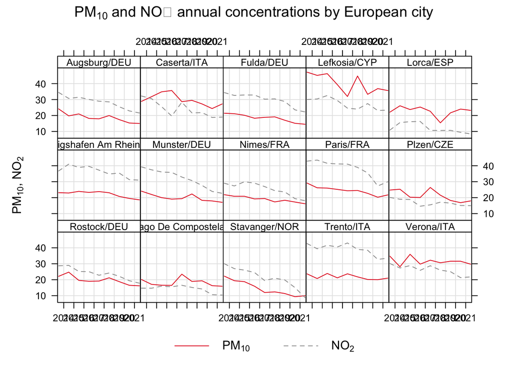

```r
library(tidyr)

# Convert back to long format
data_long <- clean_europe_data %>%
  pivot_longer(
    cols = starts_with("pm10_concentration_") | starts_with("no2_concentration_"),
    names_to = c(".value", "year"),
    names_pattern = "(pm10_concentration|no2_concentration)_(\\d+)"
  ) %>%
  mutate(year = as.integer(year))

# Randomly select 15 cities
cities_sample <- data_long %>%
  distinct(city) %>%
  sample_n(15) %>%
  pull(city)

# Aggregate and prepare for openair
data_openair_city <- data_long %>%
  filter(city %in% cities_sample) %>%
  group_by(city, year) %>%
  summarise(
    pm10 = mean(pm10_concentration, na.rm = TRUE),
    no2  = mean(no2_concentration, na.rm = TRUE),
    .groups = "drop"
  ) %>%
  mutate(date = ymd(paste0(year, "-06-30"))) %>%  # mid-year date
  select(date, city, pm10, no2)

# Plot
timePlot(
  data_openair_city,
  pollutant = c("pm10", "no2"),
  type = "city",
  main = "PM10 and NO₂ annual concentrations by European city"
)
```

# Section 1: Linear regression models

The first model we explored for prediction was the commonly seen linear regression. From previous EDA that we carried out, we used the openair package for time series of pm10 and no2 concentrations for different cities in Europe,we saw from this that linear regression should be an appropriate model. Linear regression cannot work if we have missing values, so for this we use our clean_europe_data. Our goal is to predict the pm10 concentration for 2021 (2022 contains insufficient data for testing) using previous years. We aim to test on a variety of cities to see how effective our model is for predicting pm10 for cities in Europe.

## Model equation

We decided to include the following covariates in our model:

- **population** (city size) -numeric, continuous, but has a wide range- might have to transform.
- **year** (to capture time effects) - numeric, discrete, 2013-2021 once cleaned
- **no2_concentration** we found this was strongly correlated with pm10_concentration so may contribute to prediction.
- **country_name** - categorical (we focused on european countries), we won’t use this to predict but we use it later when visualising our results.
- **latitude/longitude** - could be interesting exploration of location.

So the equation for our linear regression model can be given by:

$$\text{PM10}_{i,2021} = \beta_0 +\sum^{2020}_{year=2013} \beta_1 \cdot
\text{PM10_{i,year}} + \sum^{2020}_{year=2013} \beta_2 \cdot
\text{N02_{i,year}} +\beta_3 \cdot \text{latitude}_i + \beta_4 \cdot
\text{longitude}_i +\beta_3 \cdot \text{population}_i+ \varepsilon_i,$$

where $\varepsilon_i \sim N(0,\sigma^2)$.

## Model

Here we want to split into test and training data, where training is all of the pm_10 values for the years before 2021, and our test is our 2021 data. We use packages such as ‘carat’ that we saw in the workshop 2.3. We then create an additional split of 80%-20%, and test on our data at the very end.

```r
predictors=c(paste0("pm10_concentration_", 2013:2020),
  paste0("no2_concentration_", 2013:2020),
  "longitude", "latitude", "population")

target= "pm10_concentration_2021"

set.seed(123)
n=nrow(clean_europe_data)
train_index=sample(seq_len(n), size = 0.8 * n)

train_data=clean_europe_data[train_index, ]
test_data =clean_europe_data[-train_index, ]
actual =test_data$pm10_concentration_2021
model =lm(pm10_concentration_2021 ~ ., data = train_data[, c(predictors, target)])
summary(model)
```

```
##
## Call:
## lm(formula = pm10_concentration_2021 ~ ., data = train_data[,
##     c(predictors, target)])
##
## Residuals:
##     Min      1Q  Median      3Q     Max
## -6.4084 -0.8613  0.0128  0.8675  3.9974
##
## Coefficients:
##                           Estimate Std. Error t value Pr(>|t|)
## (Intercept)              2.386e+00  8.833e-01   2.701  0.00741 **
## pm10_concentration_2013 -1.658e-02  3.553e-02  -0.467  0.64123
## pm10_concentration_2014 -4.566e-02  4.364e-02  -1.046  0.29648
## pm10_concentration_2015  7.353e-02  5.691e-02   1.292  0.19757
## pm10_concentration_2016  2.837e-02  5.707e-02   0.497  0.61954
## pm10_concentration_2017  1.233e-01  5.170e-02   2.384  0.01788 *
## pm10_concentration_2018  1.419e-01  5.726e-02   2.479  0.01386 *
## pm10_concentration_2019  3.034e-01  6.338e-02   4.788 2.94e-06 ***
## pm10_concentration_2020  2.824e-01  5.258e-02   5.370 1.84e-07 ***
## no2_concentration_2013   1.540e-02  3.126e-02   0.493  0.62272
## no2_concentration_2014   2.785e-03  4.345e-02   0.064  0.94895
## no2_concentration_2015  -3.784e-02  4.605e-02  -0.822  0.41202
## no2_concentration_2016  -8.358e-02  4.974e-02  -1.681  0.09415 .
## no2_concentration_2017   2.713e-02  4.079e-02   0.665  0.50663
## no2_concentration_2018  -3.436e-02  5.226e-02  -0.658  0.51147
## no2_concentration_2019   1.375e-01  7.206e-02   1.908  0.05762 .
## no2_concentration_2020  -3.795e-02  5.930e-02  -0.640  0.52287
## longitude               -8.996e-03  1.115e-02  -0.806  0.42075
## latitude                -2.298e-02  1.549e-02  -1.484  0.13916
## population               1.106e-07  1.110e-07   0.996  0.32018
## ---
## Signif. codes:  0 '***' 0.001 '**' 0.01 '*' 0.05 '.' 0.1 ' ' 1
##
## Residual standard error: 1.538 on 242 degrees of freedom
## Multiple R-squared:  0.9265, Adjusted R-squared:  0.9208
## F-statistic: 160.7 on 19 and 242 DF,  p-value: < 2.2e-16
```

```r
predictions =predict(model, newdata = test_data)
```

The estimated coefficients can be interpreted as follows:

- **Intercept**: $\hat{\beta}_0 = 2.386e+00$  
  This represents the expected ${PM}_{10}$ concentration when all other variables are zero.  
  Since this situation is not realistic, the intercept is not of direct interest.
- **Pm_10_concentrations**: We see that some previous years are statistically significant in the prediction of pm10, those being the most recent years: 2020,2019,2018,2017.
- **No2_concentrations**: We see that these generally aren’t particularly statistically significant.

Longitude, latitude and population don’t appear to contribute very much to the model.

- **Model fit**: The coefficient of determination is $R^2 \approx 0.9265$.  
  This means that the model explains 92.65% of the variation in ${PM}_{10}$ concentrations.  
  While this at first may seem like a very good prediction, there are a few things we need to consider before claiming this is a very effective model.

We test our model’s fit on the linear regression assumptions:

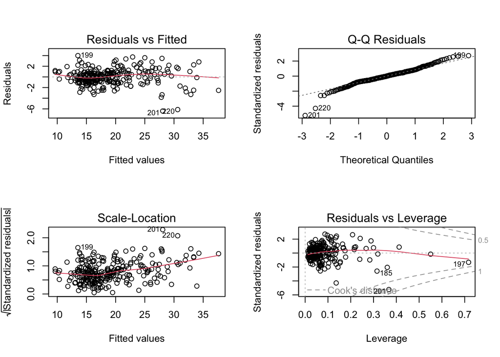

```r
par(mfrow = c(2, 2))
plot(model)
```

*Residuals vs fitted :* The residuals are fairly randomly scattered, suggesting our assumption for linearity holds.

## Model visualisation

And now we create a plot of our actual pm10 concentrations against our predicted for each city, to compare how close our model was:

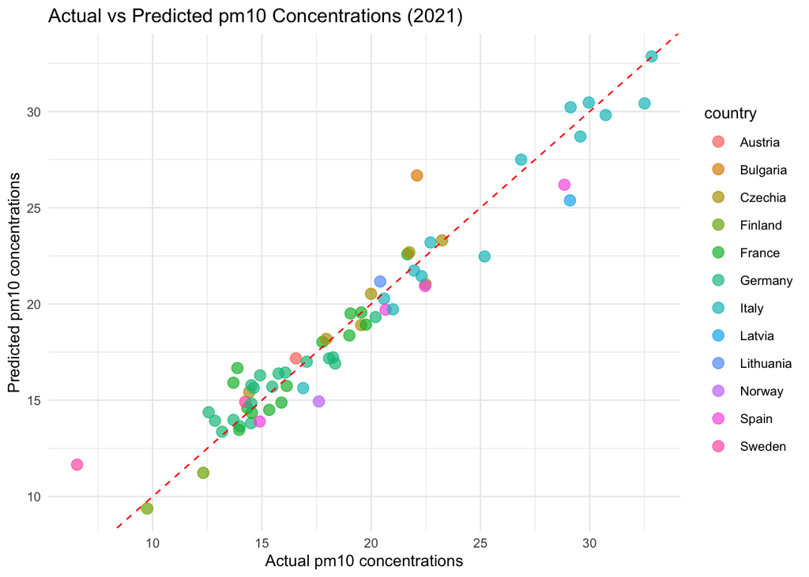

```r
library(ggplot2)

results_df <- data.frame(
  city = test_data$city,
  actual = actual,
  country = test_data$country_name,
  predicted = predictions
)

ggplot(results_df, aes(x = actual, y = predicted, color = country)) +
  geom_point( alpha = 0.7, size = 3) +
  geom_abline(intercept = 0, slope = 1, color = "red", linetype = "dashed") +
  labs(
    title = "Actual vs Predicted pm10 Concentrations (2021)",
    x = "Actual pm10 concentrations",
    y = "Predicted pm10 concentrations", color = "country"
  ) +
  theme_minimal(base_size = 10)+ theme(legend.position = "right")
```

Evidently, we have a very large amount of temporal correlation, making our model effective for predicting recent years based on previous years. To minimise the temporal correlation we could remove the pm10 rows.